# Análisis de Campañas de Marketing

## 6.3 Comportamiento de Gasto (Monto)teniendo en cuenta la última campaña

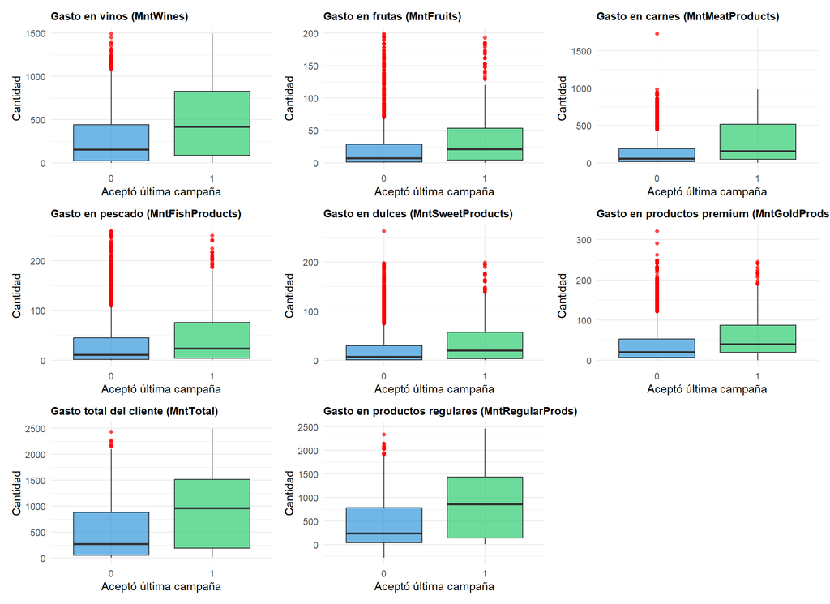

Figure 6.5: Distribución de variables de gastos según (Response, 0 = No, 1 = Sí Aceptó última campaña).

```r
data_temp <- datos_sin_inconsistencia_v1

vars_graph <- c("MntWines", "MntFruits", "MntMeatProducts", "MntFishProducts",
                "MntSweetProducts", "MntGoldProds", "MntTotal", "MntRegularProds")

plots <- lapply(vars_graph, function(v){
  ggplot(data_temp, aes(x = factor(Response), y = .data[[v]], fill = factor(Response))) +
    geom_boxplot(outlier.colour = "red", outlier.shape = 16, outlier.size = 1.5, alpha = 0.7) +
    scale_fill_manual(values = c("#3498db", "#2ecc71")) +
    labs(title = diccionario_vars[[v]],
         x = "Aceptó última campaña",
         y = "Cantidad") +
    theme_minimal() +
    theme(legend.position = "none",
          plot.title = element_text(size = 10, face = "bold"))
})

wrap_plots(plots, ncol = 3)
```

```r
data_temp <- datos_finales_sin_errores_ni_inconsistencias

lista_resultados <- list()
N_TOTAL <- nrow(data_temp)
vars_graph <- c("MntWines", "MntFruits", "MntMeatProducts", "MntFishProducts",
                "MntSweetProducts", "MntGoldProds", "MntTotal", "MntRegularProds")


for(v in vars_graph) {

  # División de datos por target
  g0 <- as.numeric(data_temp[[v]][which(data_temp$Response == 0)])
  g1 <- as.numeric(data_temp[[v]][which(data_temp$Response == 1)])

  procesar <- function(vec, label_cmp) {

    n_total_subgrupo <- length(vec)
    n_na <- sum(is.na(vec))
    pct_na <- (n_na / n_total_subgrupo) * 100

    vec_clean <- na.omit(vec)
    n_subdataset <- length(vec_clean)
    if(n_subdataset == 0) return(NULL)

    # --- Cálculo de Outliers (Regla 1.5 IQR) ---
    q1 <- quantile(vec_clean, 0.25)
    q3 <- quantile(vec_clean, 0.75)
    iqr_val <- q3 - q1
    lim_inf <- q1 - 1.5 * iqr_val
    lim_sup <- q3 + 1.5 * iqr_val

    # Identificar outliers
    outliers <- vec_clean[vec_clean < lim_inf | vec_clean > lim_sup]
    n_outliers <- length(outliers)

    # Porcentajes
    pct_subdataset <- (n_outliers / n_subdataset) * 100
    pct_global <- (n_outliers / N_TOTAL) * 100

    # --- Generación de estadísticos con summarytools ---
    descr(vec_clean,
          stats = c("n.valid","min","q1","med","q3","max","mean","sd","cv"),
          transpose = TRUE) %>%
      tb() %>%
      rename(Estadistico = 1) %>%
      mutate(
        Variable = v,
        Response = label_cmp,
        Outliers_N = n_outliers,
        `Pct_Outlier_Subgrupo` = pct_subdataset,
        `Pct_Outlier_Global` = pct_global,
        Datos_NA = n_na,
        Pct_Datos_NA = pct_na
      )
  }

  lista_resultados[[paste0(v, "_0")]] <- procesar(g0, 0)
  lista_resultados[[paste0(v, "_1")]] <- procesar(g1, 1)
}

# 2. Unir resultados en una sola tabla
tabla_maestra <- bind_rows(lista_resultados) %>%
  select(Variable, everything(), -Estadistico, Outliers_N, `Pct_Outlier_Subgrupo`, `Pct_Outlier_Global`) %>%
  mutate(
    Variable = str_trim(as.character(Variable)),
    Variable = ifelse(
      Variable %in% names(diccionario_vars),
      unname(diccionario_vars[Variable]),
      Variable
    )
  )

knitr::kable(tabla_maestra,
             digits = 2,
             caption = "Análisis de Montos de gastos por aceptación de la última campaña",
             format = "html") %>%   kable_styling(bootstrap_options = c("bordered", "striped", "hover"), full_width = F, font_size = 11)%>% scroll_box(width = "700px")
```

Table 6.2: Análisis de Montos de gastos por aceptación de la última campaña

| Variable | n.valid | min | q1 | med | q3 | max | mean | sd | cv | Response | Outliers_N | Pct_Outlier_Subgrupo | Pct_Outlier_Global | Datos_NA | Pct_Datos_NA |
| --- | --- | --- | --- | --- | --- | --- | --- | --- | --- | --- | --- | --- | --- | --- | --- |
| Gasto en vinos (MntWines) | 1726 | -13 | 22 | 158.0 | 448 | 1493 | 272.42 | 307.64 | 1.13 | 0 | 37 | 2.14 | 1.81 | 0 | 0 |
| Gasto en vinos (MntWines) | 313 | -34 | 91 | 448.0 | 847 | 1492 | 498.35 | 424.74 | 0.85 | 1 | 0 | 0.00 | 0.00 | 0 | 0 |
| Gasto en frutas (MntFruits) | 1726 | 0 | 1 | 7.0 | 29 | 199 | 24.23 | 38.17 | 1.58 | 0 | 198 | 11.47 | 9.71 | 0 | 0 |
| Gasto en frutas (MntFruits) | 313 | 0 | 4 | 21.0 | 53 | 193 | 38.11 | 46.23 | 1.21 | 1 | 24 | 7.67 | 1.18 | 0 | 0 |
| Gasto en carnes (MntMeatProducts) | 1726 | 0 | 14 | 57.0 | 188 | 1725 | 142.73 | 195.74 | 1.37 | 0 | 154 | 8.92 | 7.55 | 0 | 0 |
| Gasto en carnes (MntMeatProducts) | 313 | 1 | 47 | 161.0 | 514 | 981 | 295.30 | 289.88 | 0.98 | 1 | 0 | 0.00 | 0.00 | 0 | 0 |
| Gasto en pescado (MntFishProducts) | 1726 | 0 | 2 | 11.0 | 45 | 259 | 35.25 | 53.22 | 1.51 | 0 | 183 | 10.60 | 8.97 | 0 | 0 |
| Gasto en pescado (MntFishProducts) | 313 | 0 | 4 | 24.0 | 76 | 250 | 50.61 | 61.45 | 1.21 | 1 | 19 | 6.07 | 0.93 | 0 | 0 |
| Gasto en dulces (MntSweetProducts) | 1726 | 0 | 1 | 7.0 | 30 | 262 | 25.31 | 40.39 | 1.60 | 0 | 201 | 11.65 | 9.86 | 0 | 0 |
| Gasto en dulces (MntSweetProducts) | 313 | 0 | 3 | 20.0 | 57 | 198 | 38.62 | 46.52 | 1.20 | 1 | 18 | 5.75 | 0.88 | 0 | 0 |
| Gasto en productos premium (MntGoldProds) | 1726 | 0 | 7 | 21.0 | 53 | 321 | 40.55 | 49.77 | 1.23 | 0 | 148 | 8.57 | 7.26 | 0 | 0 |
| Gasto en productos premium (MntGoldProds) | 313 | 0 | 20 | 40.0 | 88 | 245 | 62.35 | 58.34 | 0.94 | 1 | 15 | 4.79 | 0.74 | 0 | 0 |
| Gasto total del cliente (MntTotal) | 1726 | 5 | 62 | 316.5 | 946 | 2525 | 540.50 | 553.58 | 1.02 | 0 | 5 | 0.29 | 0.25 | 0 | 0 |
| Gasto total del cliente (MntTotal) | 313 | 17 | 246 | 1062.0 | 1617 | 2525 | 983.34 | 716.27 | 0.73 | 1 | 0 | 0.00 | 0.00 | 0 | 0 |
| Gasto en productos regulares (MntRegularProds) | 1726 | 4 | 49 | 276.0 | 883 | 2429 | 499.94 | 528.06 | 1.06 | 0 | 6 | 0.35 | 0.29 | 0 | 0 |
| Gasto en productos regulares (MntRegularProds) | 313 | 6 | 216 | 967.0 | 1517 | 2491 | 920.98 | 695.89 | 0.76 | 1 | 0 | 0.00 | 0.00 | 0 | 0 |

Viendo la 6.5 y la Tabla 6.2 se observa que: Gasto en vinos (MntWines), Gasto en frutas (MntFruits), Gasto en carnes (MntMeatProducts), Gasto en pescado (MntFishProducts), Gasto en dulces (MntSweetProducts), Gasto en productos premium (MntGoldProds), Gasto en productos regulares (MntRegularProds) y Gasto total del cliente (MntTotal), tienen una diferencia entre quienes aceptan y no aceptan ️la última campaña,los que aceptan tienen mayor gasto. Es una variable predictora potencial.

Siendo Gasto en vinos (MntWines), Gasto en productos regulares (MntRegularProds) y Gasto total del cliente (MntTotal), las que pueden tener más potencia predictora, y siendo Gasto en frutas (MntFruits), Gasto en pescado (MntFishProducts), Gasto en dulces (MntSweetProducts) las que muestran menos diferencia entre grupos, menos poder predictivo.

## 6.4 Canales de Venta teniendo en cuenta la última campaña

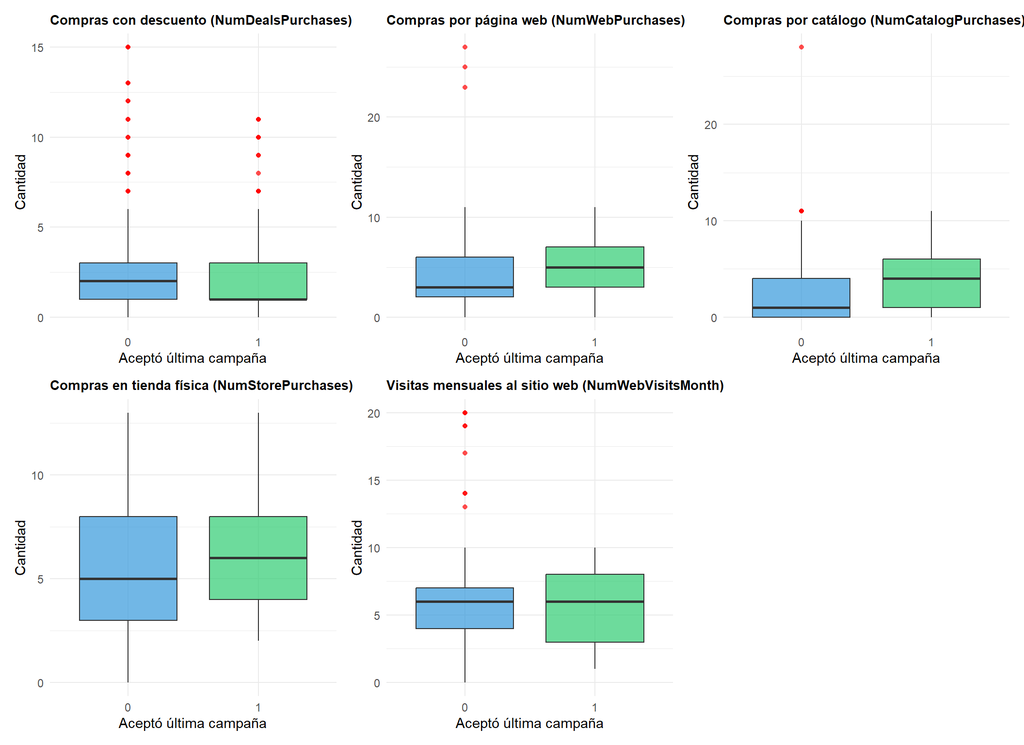

Figure 6.6: Distribución de variables de canales de venta según (Response, 0 = No, 1 = Sí Aceptó última campaña).

```r
data_temp <- datos_sin_inconsistencia_v1

vars_graph <- c("NumDealsPurchases", "NumWebPurchases", "NumCatalogPurchases",
                  "NumStorePurchases", "NumWebVisitsMonth")

plots <- lapply(vars_graph, function(v){
  ggplot(data_temp, aes(x = factor(Response), y = .data[[v]], fill = factor(Response))) +
    geom_boxplot(outlier.colour = "red", outlier.shape = 16, outlier.size = 1.5, alpha = 0.7) +
    scale_fill_manual(values = c("#3498db", "#2ecc71")) +
    labs(title = diccionario_vars[[v]],
         x = "Aceptó última campaña",
         y = "Cantidad") +
    theme_minimal() +
    theme(legend.position = "none",
          plot.title = element_text(size = 10, face = "bold"))
})

wrap_plots(plots, ncol = 3)
```

```r
data_temp <- datos_finales_sin_errores_ni_inconsistencias

lista_resultados <- list()
N_TOTAL <- nrow(data_temp)
vars_graph <- c("NumDealsPurchases", "NumWebPurchases", "NumCatalogPurchases",
                  "NumStorePurchases", "NumWebVisitsMonth")


for(v in vars_graph) {

  # División de datos por target
  g0 <- as.numeric(data_temp[[v]][which(data_temp$Response == 0)])
  g1 <- as.numeric(data_temp[[v]][which(data_temp$Response == 1)])

  procesar <- function(vec, label_cmp) {

    n_total_subgrupo <- length(vec)
    n_na <- sum(is.na(vec))
    pct_na <- (n_na / n_total_subgrupo) * 100

    vec_clean <- na.omit(vec)
    n_subdataset <- length(vec_clean)
    if(n_subdataset == 0) return(NULL)

    # --- Cálculo de Outliers (Regla 1.5 IQR) ---
    q1 <- quantile(vec_clean, 0.25)
    q3 <- quantile(vec_clean, 0.75)
    iqr_val <- q3 - q1
    lim_inf <- q1 - 1.5 * iqr_val
    lim_sup <- q3 + 1.5 * iqr_val

    # Identificar outliers
    outliers <- vec_clean[vec_clean < lim_inf | vec_clean > lim_sup]
    n_outliers <- length(outliers)

    # Porcentajes
    pct_subdataset <- (n_outliers / n_subdataset) * 100
    pct_global <- (n_outliers / N_TOTAL) * 100

    # --- Generación de estadísticos con summarytools ---
    descr(vec_clean,
          stats = c("n.valid","min","q1","med","q3","max","mean","sd","cv"),
          transpose = TRUE) %>%
      tb() %>%
      rename(Estadistico = 1) %>%
      mutate(
        Variable = v,
        Response = label_cmp,
        Outliers_N = n_outliers,
        `Pct_Outlier_Subgrupo` = pct_subdataset,
        `Pct_Outlier_Global` = pct_global,
        Datos_NA = n_na,
        Pct_Datos_NA = pct_na
      )
  }

  lista_resultados[[paste0(v, "_0")]] <- procesar(g0, 0)
  lista_resultados[[paste0(v, "_1")]] <- procesar(g1, 1)
}

# 2. Unir resultados en una sola tabla
tabla_maestra <- bind_rows(lista_resultados) %>%
  select(Variable, everything(), -Estadistico, Outliers_N, `Pct_Outlier_Subgrupo`, `Pct_Outlier_Global`) %>%
  mutate(
    Variable = str_trim(as.character(Variable)),
    Variable = ifelse(
      Variable %in% names(diccionario_vars),
      unname(diccionario_vars[Variable]),
      Variable
    )
  )

knitr::kable(tabla_maestra,
             digits = 2,
             caption = "Análisis de canales de venta por aceptación de última Campaña",
             format = "html") %>%   kable_styling(bootstrap_options = c("bordered", "striped", "hover"), full_width = F, font_size = 11) %>% scroll_box(width = "700px")
```

Table 6.3: Análisis de canales de venta por aceptación de última Campaña

| Variable | n.valid | min | q1 | med | q3 | max | mean | sd | cv | Response | Outliers_N | Pct_Outlier_Subgrupo | Pct_Outlier_Global | Datos_NA | Pct_Datos_NA |
| --- | --- | --- | --- | --- | --- | --- | --- | --- | --- | --- | --- | --- | --- | --- | --- |
| Compras con descuento (NumDealsPurchases) | 1726 | 0 | 1 | 2 | 3 | 15 | 2.32 | 1.85 | 0.80 | 0 | 57 | 3.30 | 2.80 | 0 | 0 |
| Compras con descuento (NumDealsPurchases) | 313 | 0 | 1 | 1 | 3 | 11 | 2.33 | 2.11 | 0.91 | 1 | 17 | 5.43 | 0.83 | 0 | 0 |
| Compras por página web (NumWebPurchases) | 1726 | 0 | 2 | 3 | 6 | 27 | 3.94 | 2.75 | 0.70 | 0 | 3 | 0.17 | 0.15 | 0 | 0 |
| Compras por página web (NumWebPurchases) | 313 | 0 | 3 | 5 | 7 | 11 | 5.08 | 2.57 | 0.51 | 1 | 0 | 0.00 | 0.00 | 0 | 0 |
| Compras por catálogo (NumCatalogPurchases) | 1726 | 0 | 0 | 1 | 4 | 28 | 2.37 | 2.64 | 1.12 | 0 | 10 | 0.58 | 0.49 | 0 | 0 |
| Compras por catálogo (NumCatalogPurchases) | 313 | 0 | 1 | 4 | 6 | 11 | 4.19 | 3.12 | 0.74 | 1 | 0 | 0.00 | 0.00 | 0 | 0 |
| Compras en tienda física (NumStorePurchases) | 1726 | 0 | 3 | 5 | 8 | 13 | 5.76 | 3.25 | 0.56 | 0 | 0 | 0.00 | 0.00 | 0 | 0 |
| Compras en tienda física (NumStorePurchases) | 313 | 2 | 4 | 6 | 8 | 13 | 6.06 | 3.09 | 0.51 | 1 | 0 | 0.00 | 0.00 | 0 | 0 |
| Visitas mensuales al sitio web (NumWebVisitsMonth) | 1726 | 0 | 4 | 6 | 7 | 20 | 5.35 | 2.40 | 0.45 | 0 | 9 | 0.52 | 0.44 | 0 | 0 |
| Visitas mensuales al sitio web (NumWebVisitsMonth) | 313 | 1 | 3 | 6 | 8 | 10 | 5.29 | 2.55 | 0.48 | 1 | 0 | 0.00 | 0.00 | 0 | 0 |

Viendo la 6.6 y la Tabla 6.3 se observa que:

Compras por catálogo (NumCatalogPurchases), Compras por página web (NumWebPurchases) y Compras en tienda física (NumStorePurchases) presentan una diferencia entre quienes aceptan y no aceptan la última campaña; los clientes que aceptan tienden a realizar un mayor número de transacciones en estos canales. Son variables predictoras potenciales.

Siendo Compras por catálogo (NumCatalogPurchases) la que parece tener más potencia predictora, ya que posee la separación más clara entre las medianas y los rangos intercuartílicos de ambos grupos.

Por el contrario, Visitas mensuales al sitio web (NumWebVisitsMonth) y Compras con descuento (NumDealsPurchases) son las que muestran menos potencia predictora, debido a que las cajas de ambos grupos están casi al mismo nivel y se solapan significativamente, lo que indica que el comportamiento es muy similar independientemente de si aceptaron la campaña o no. Aún así vamos a revisarlas más a profundidad debido a que por cuartiles podemos ver algunas diferencias.

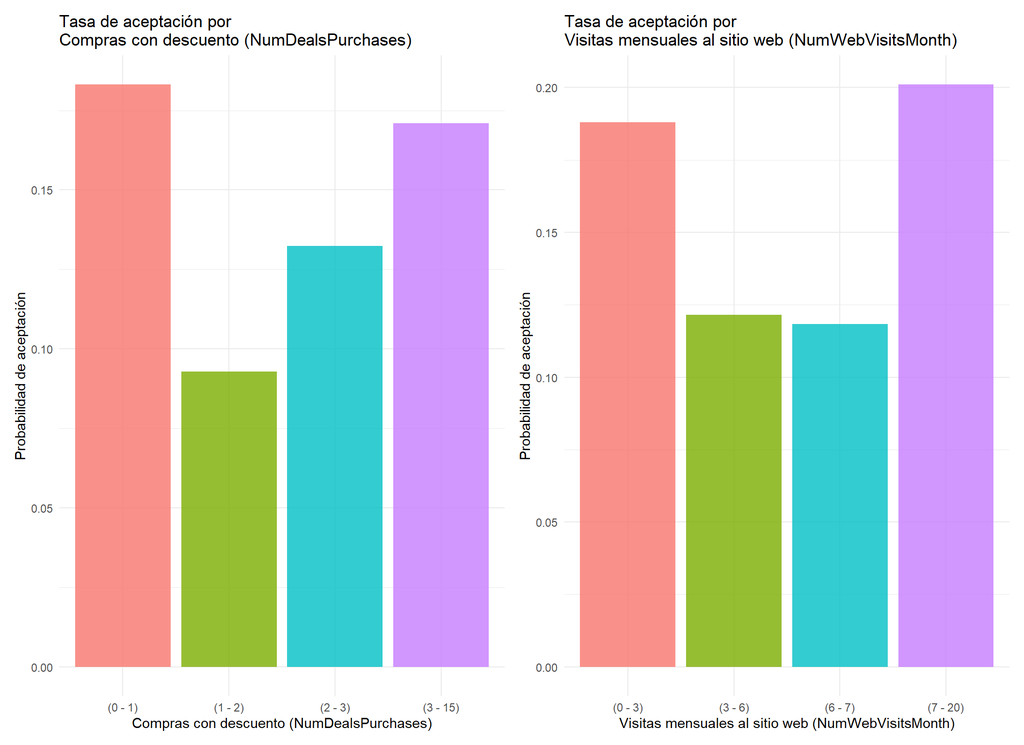

Figure 6.7: Datos de canales (Response, 0 = No, 1 = Sí Aceptó última campaña).

```r
data_temp <- datos_finales_sin_errores_ni_inconsistencias


cuartiles <- quantile(data_temp$NumDealsPurchases,
                      probs = c(0, 0.25, 0.5, 0.75, 1),
                      na.rm = TRUE)
labels_q <- paste0(
  "(", round(cuartiles[-5]), " - ", round(cuartiles[-1]), ")"
)

data_temp <- data_temp %>%
  mutate(
    NumDealsPurchases = cut(
      NumDealsPurchases,
      breaks = cuartiles,
      include.lowest = TRUE,
      labels = labels_q
    )
  )

cuartiles <- quantile(data_temp$NumWebVisitsMonth,
                      probs = c(0, 0.25, 0.5, 0.75, 1),
                      na.rm = TRUE)
labels_q <- paste0(
  "(", round(cuartiles[-5]), " - ", round(cuartiles[-1]), ")"
)

data_temp <- data_temp %>%
  mutate(
    NumWebVisitsMonth = cut(
      NumWebVisitsMonth,
      breaks = cuartiles,
      include.lowest = TRUE,
      labels = labels_q
    )
  )


vars_graph <- c("NumDealsPurchases", "NumWebVisitsMonth")

plots <- lapply(vars_graph, function(v){

  data_temp %>%
    group_by(.data[[v]]) %>%
    summarise(
      tasa = mean(Response),
      n = n(),
      .groups = "drop"
    ) %>%
    ggplot(aes(x = factor(.data[[v]]), y = tasa, fill = factor(.data[[v]]))) +
    geom_col(alpha = 0.8) +
    labs(
      title = paste0("Tasa de aceptación por \n", diccionario_vars[[v]]),
      x = diccionario_vars[[v]],
      y = "Probabilidad de aceptación"
    ) +
    theme_minimal() +
    theme(legend.position = "none")
})

wrap_plots(plots, ncol = 2)
```

En la figura 6.7 se ve que:

- Compras con descuento (NumDealsPurchases) presenta una probabilidad de aceptación que varia según el volumen de compras realizadas. Aunque el grupo con más compras (3-15) tiene una tasa alta, el comportamiento no es lineal (baja en el segundo cuartil y vuelve a subir), lo que sugiere que genera señal predictiva, pero su relación con la aceptación es compleja.
- Visitas mensuales al sitio web (NumWebVisitsMonth) presenta que la probabilidad de aceptación es diferente según la frecuencia de visitas al sitio. Se observa que los usuarios con un nivel de interacción muy alto (rango de 7-20 visitas) tienen la tasa de conversión más elevada, lo que sugiere que el interés digital es un indicador relevante y que la variable puede tener poder predictivo.

Este último análisis puede aplicar sobretodo en modelos de clasificacion de arboles que puede manejar rangos de variables, o categorizarlas para facilitar su entendimiento en otro tipo de modelos.

## 6.5 Respuesta a Campañas (Marketing) y Lealtad (Fidelidad)

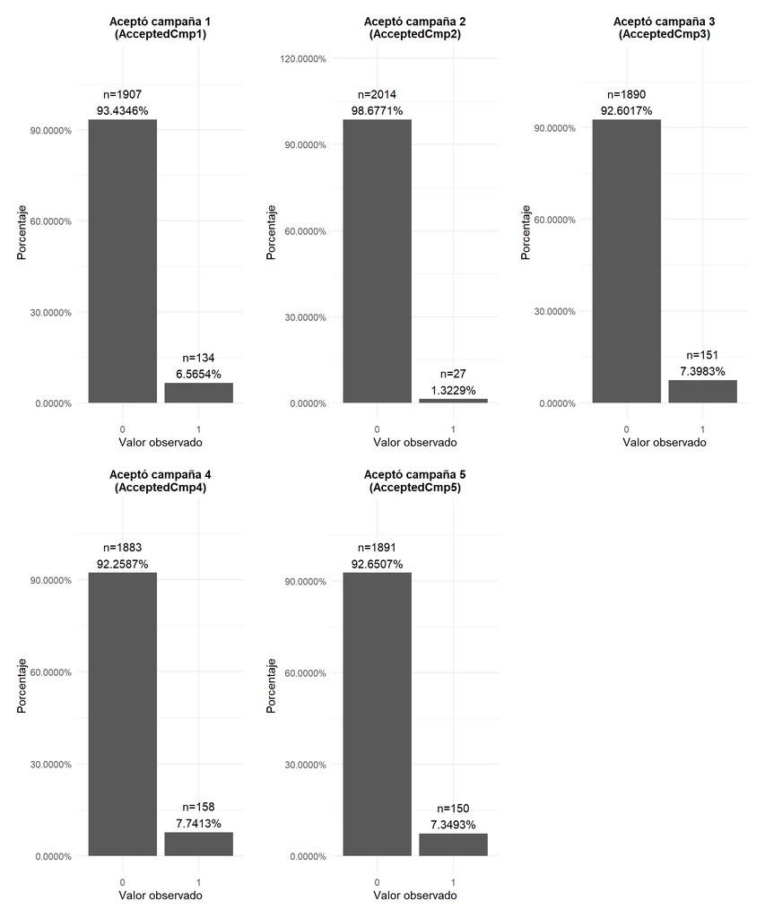

Figure 6.8: Distribución porcentual de las variables de aceptación de campañas (Binarias). Se incluyen valores faltantes como categoría explícita.

```r
vars <- c("AcceptedCmp1", "AcceptedCmp2", "AcceptedCmp3",
                    "AcceptedCmp4", "AcceptedCmp5")

data_temp <- datos_sin_duplicados

plots <- lapply(vars, function(v){

  conteo <- as.data.frame(table(data_temp[[v]], useNA = "ifany"))
  colnames(conteo) <- c("valor", "n")

  conteo$pct <- conteo$n / sum(conteo$n)

  ymax <- max(conteo$pct) * 1.20

  ggplot(conteo, aes(x = factor(valor), y = pct)) +
    geom_col() +
    geom_text(aes(label = paste0("n=", n, "\n", sprintf("%.4f%%", 100*pct))),
              vjust = -0.2, size = 3.8) +
    scale_y_continuous(labels = function(x) sprintf("%.4f%%", 100*x),
                       limits = c(0, ymax)) +
    labs(
      title = stringr::str_wrap(diccionario_vars[[v]], width = 30),
      x = "Valor observado",
      y = "Porcentaje"
    ) +
    theme_minimal() +
    theme(
      plot.title = element_text(size = 11, face = "bold", hjust = 0.5),
      plot.margin = margin(10, 10, 10, 10)
    )
})

wrap_plots(plots, ncol = 3)
```

Para las gráficas de las campañas anteriores (AcceptedCmp1 a AcceptedCmp5) mostradas en la figura 6.8, que muestran la distribución de aceptación individual, podemos ver lo siguiente:

Aceptó campaña 1 (AcceptedCmp1), Aceptó campaña 3 (AcceptedCmp3), Aceptó campaña 4 (AcceptedCmp4) y Aceptó campaña 5 (AcceptedCmp5) presentan una distribución muy similar, donde la gran mayoría de los clientes (más del 90%) no aceptó dichas ofertas. Sin embargo, el pequeño porcentaje que sí las aceptó (entre el 6% y 7.7%) suele ser un indicador crítico de lealtad. Son variables predictoras potenciales muy buenas para identificar el perfil de cliente según el objetivo que tenemos de predecir si acepta o no la última campaña.

Las variables de Aceptó campaña 4 (AcceptedCmp4) y Aceptó campaña 3 (AcceptedCmp3) son las que podrían tener más potencia predictora dentro de este grupo, debido a que tienen un volumen de aceptación ligeramente superior (7.74% y 7.40% respectivamente), lo que ofrece un poco más de datos al modelo para encontrar patrones del perfil del cliente.

Por el contrario, Aceptó campaña 2 (AcceptedCmp2) es la que posee menos potencia predictora, ya que solo el 1.32% de los clientes la aceptó. Al tener tan pocos casos positivos (solamente 27 personas), es muy difícil que un modelo estadístico o de machine learning pueda extraer una regla general confiable de esta variable pero puede ser necesaria debido a la cosistencia de la data.

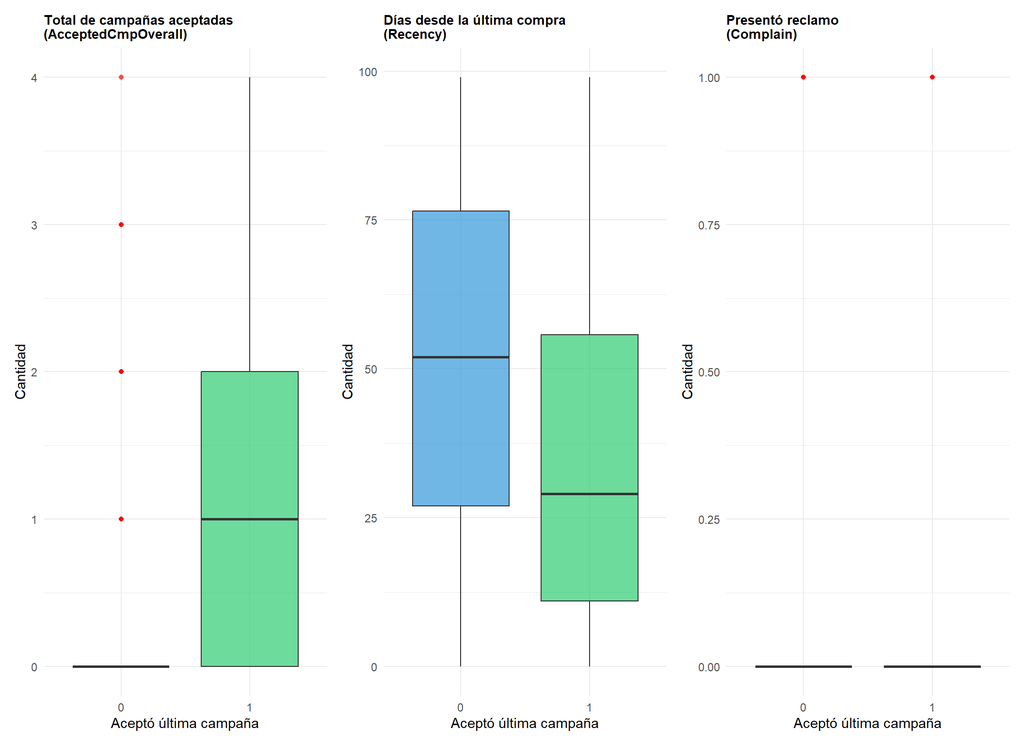

Figure 6.9: Distribución de variables para (Response, 0 = No, 1 = Sí Aceptó última campaña).

```r
data_temp <- datos_sin_inconsistencia_v1

vars_graph <- c("AcceptedCmpOverall","Recency", "Complain")

plots <- lapply(vars_graph, function(v){
  ggplot(data_temp, aes(x = factor(Response), y = .data[[v]], fill = factor(Response))) +
    geom_boxplot(outlier.colour = "red", outlier.shape = 16, outlier.size = 1.5, alpha = 0.7) +
    scale_fill_manual(values = c("#3498db", "#2ecc71")) +
    labs(title = gsub("\\(", "\n(", diccionario_vars[[v]]),
         x = "Aceptó última campaña",
         y = "Cantidad") +
    theme_minimal() +
    theme(legend.position = "none",
          plot.title = element_text(size = 10, face = "bold"))
})

wrap_plots(plots, ncol = 3)
```

```r
data_temp <- datos_finales_sin_errores_ni_inconsistencias

lista_resultados <- list()
N_TOTAL <- nrow(data_temp)
vars_graph <- c("AcceptedCmpOverall","Recency", "Complain")


for(v in vars_graph) {

  # División de datos por target
  g0 <- as.numeric(data_temp[[v]][which(data_temp$Response == 0)])
  g1 <- as.numeric(data_temp[[v]][which(data_temp$Response == 1)])

  procesar <- function(vec, label_cmp) {

    n_total_subgrupo <- length(vec)
    n_na <- sum(is.na(vec))
    pct_na <- (n_na / n_total_subgrupo) * 100

    vec_clean <- na.omit(vec)
    n_subdataset <- length(vec_clean)
    if(n_subdataset == 0) return(NULL)

    # --- Cálculo de Outliers (Regla 1.5 IQR) ---
    q1 <- quantile(vec_clean, 0.25)
    q3 <- quantile(vec_clean, 0.75)
    iqr_val <- q3 - q1
    lim_inf <- q1 - 1.5 * iqr_val
    lim_sup <- q3 + 1.5 * iqr_val

    # Identificar outliers
    outliers <- vec_clean[vec_clean < lim_inf | vec_clean > lim_sup]
    n_outliers <- length(outliers)

    # Porcentajes
    pct_subdataset <- (n_outliers / n_subdataset) * 100
    pct_global <- (n_outliers / N_TOTAL) * 100

    # --- Generación de estadísticos con summarytools ---
    descr(vec_clean,
          stats = c("n.valid","min","q1","med","q3","max","mean","sd","cv"),
          transpose = TRUE) %>%
      tb() %>%
      rename(Estadistico = 1) %>%
      mutate(
        Variable = v,
        Response = label_cmp,
        Outliers_N = n_outliers,
        `Pct_Outlier_Subgrupo` = pct_subdataset,
        `Pct_Outlier_Global` = pct_global,
        Datos_NA = n_na,
        Pct_Datos_NA = pct_na
      )
  }

  lista_resultados[[paste0(v, "_0")]] <- procesar(g0, 0)
  lista_resultados[[paste0(v, "_1")]] <- procesar(g1, 1)
}

# 2. Unir resultados en una sola tabla
tabla_maestra <- bind_rows(lista_resultados) %>%
  select(Variable, everything(), -Estadistico, Outliers_N, `Pct_Outlier_Subgrupo`, `Pct_Outlier_Global`) %>%
  mutate(
    Variable = str_trim(as.character(Variable)),
    Variable = ifelse(
      Variable %in% names(diccionario_vars),
      unname(diccionario_vars[Variable]),
      Variable
    )
  )

knitr::kable(tabla_maestra,
             digits = 2,
             caption = "Análisis de Datos de aceptación y fidelidad por aceptación de la última Campaña",
             format = "html") %>%   kable_styling(bootstrap_options = c("bordered", "striped", "hover"), full_width = F, font_size = 11) %>% scroll_box(width = "700px")
```

Table 6.4: Análisis de Datos de aceptación y fidelidad por aceptación de la última Campaña

| Variable | n.valid | min | q1 | med | q3 | max | mean | sd | cv | Response | Outliers_N | Pct_Outlier_Subgrupo | Pct_Outlier_Global | Datos_NA | Pct_Datos_NA |
| --- | --- | --- | --- | --- | --- | --- | --- | --- | --- | --- | --- | --- | --- | --- | --- |
| Total de campañas aceptadas (AcceptedCmpOverall) | 1726 | 0 | 0 | 0 | 0 | 4 | 0.18 | 0.48 | 2.65 | 0 | 254 | 14.72 | 12.46 | 0 | 0 |
| Total de campañas aceptadas (AcceptedCmpOverall) | 313 | 0 | 0 | 1 | 2 | 4 | 0.98 | 1.11 | 1.13 | 1 | 0 | 0.00 | 0.00 | 0 | 0 |
| Días desde la última compra (Recency) | 1726 | 0 | 27 | 52 | 76 | 99 | 51.46 | 28.50 | 0.55 | 0 | 0 | 0.00 | 0.00 | 0 | 0 |
| Días desde la última compra (Recency) | 313 | 0 | 11 | 29 | 56 | 99 | 34.85 | 27.34 | 0.78 | 1 | 0 | 0.00 | 0.00 | 0 | 0 |
| Presentó reclamo (Complain) | 1726 | 0 | 0 | 0 | 0 | 1 | 0.01 | 0.10 | 10.34 | 0 | 16 | 0.93 | 0.78 | 0 | 0 |
| Presentó reclamo (Complain) | 313 | 0 | 0 | 0 | 0 | 1 | 0.01 | 0.10 | 10.18 | 1 | 3 | 0.96 | 0.15 | 0 | 0 |

Viendo la 6.9 y la Tabla 6.4 se observa que: El Total de campañas aceptadas (AcceptedCmpOverall) y Días desde la última compra (Recency) presentan una diferencia muy marcada entre quienes aceptan y no aceptan la última campaña. En el primer caso, quienes aceptan tienen un historial de aceptación previo mucho mayor, y en el segundo, los que aceptan tienden a haber comprado mucho más recientemente. Son variables predictoras con un potencial altísimo.

Siendo Total de campañas aceptadas (AcceptedCmpOverall) la que muestra la mayor potencia predictora de todo el conjunto, ya que la separación entre los grupos es casi absoluta (la mayoría de los que no aceptaron tienen un histórico de cero campañas previas). Días desde la última compra (Recency) también muestra un poder muy sólido, con medianas claramente desplazadas. En un modelo toca validar si es posible incluir el Total de campañas aceptadas (AcceptedCmpOverall) debido a que puede causar un sesgo fuerte y terminar dependiendo el modelo de una sola variable.